# Modeling S&P Composite using GARCH model

Haining Zhang & Qinqing Liu

4/6/2017

## 1.Introduction

The volatility of this S&P 500 stock index returns can be seen as a measurement of the risk for investment and provides essential information for the investors to make the correct decisions. The S&P Composite data set is collected by Yale Department of Economics (https://www.quandl.com/data/YALE/SPCOMP-S-P- Composite).

This data set consists of monthly stock price, dividends, and earnings data and the consumer price index (to allow conversion to real values), etc, all starting January 1871. We delete NA values in first 10 years and get the data over the period Jan, 1881 through Dec, 2016. Time series plot for all 9 variables shows as follows. In this dataset, CPI is the Consumer Price Index; Dividend is a distribution of a portion of a company’s earnings; Earnings is an after-tax net income of the company; Long interest Rates refer to government bonds maturing in ten years; Real Price are adjusted for general price level changes over time; Cyclically Adjusted PE. Ratio is defined as price divided by the average of ten years of earnings, adjusted for inflation.

The dataset shows as follows:

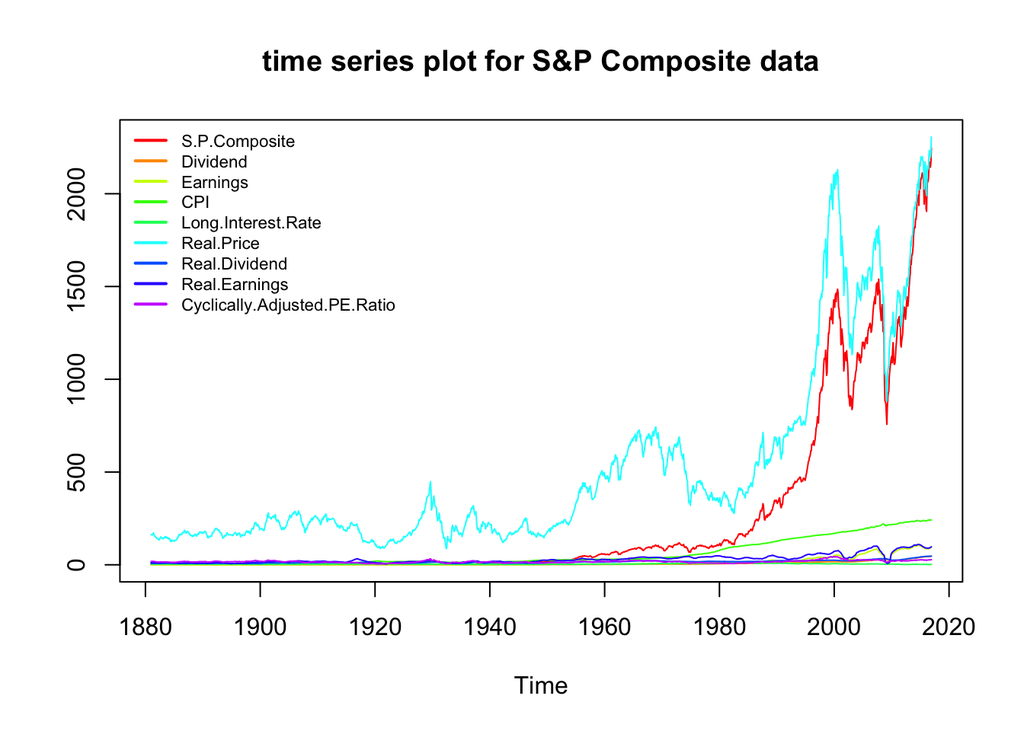

## 2. Goal of Analysis

In order to follow the bond market, it is important to learn about the S&P Composite index of stocks because the volatility of this S&P Composite stock index returns can be seen as a measurement of the risk for investment and provides essential information for the investors to make the correct decisions.

The S&P Composite measures the value of stocks of the 500 largest corporations by market capitalization listed on the New York Stock Exchange or Nasdaq Composite. Standard & Poor’s intention is to have a price that provides a quick look at the stock market and economy. Also, the S&P Composite is considered as an effective representation for the economy due to its inclusion of 500 companies, which covers all areas of the United States and across all industries. Through financial time series analysis, we can access, visualize and analyze historic time-series data.

In this case, we used the GARCH-M model including ARMA, GARCH model and linear regression with several extraneous predictors as following, which can be used to forecast the S&P Composite Stock Index Returns in the following years.

$$\left\{
\begin{aligned}
X_t&=\beta'z_t+y_t^* \hspace{4cm} (1)\\
\phi(B)y_t^*&=\theta(B)y_t \hspace{4.38cm} (2)\\
y_{t}&=\sigma_t\varepsilon_t \hspace{4.83cm}(3)\\
\sigma_t^2&=\alpha_0+\sum_{j=1}^m\alpha_j y_{t-j}^2+\sum_{j=1}^s\beta_j \sigma_{t-j}^2 \hspace{1cm}(4)\\
\end{aligned}
\right.$$

where $\beta'z_t$ is a function of exogenous predictors.

## 3. Comprehensive Data Analysis.

### (1) Linear Regression.

Firstly, we fit a full linear regression model with Dividend, Earnings, Real Dividend, Real Earnings, CPI (Consumer Price Index), Long Interest Rate, Real Price and Cyclically Adjusted PE Ratio and obtain regression residuals.

```
##
## Call:
## lm(formula = S.P.Composite ~ ., data = data2)
##
## Residuals:
##     Min      1Q  Median      3Q     Max
## -84.312 -18.255  -2.383  20.032  73.674
##
## Coefficients:
##                                Estimate Std. Error t value Pr(>|t|)
## (Intercept)                  157.412098   4.405286  35.733  < 2e-16 ***
## Dividend                      30.566873   0.757761  40.338  < 2e-16 ***
## Earnings                       4.050867   0.292287  13.859  < 2e-16 ***
## CPI                           -0.757145   0.047086 -16.080  < 2e-16 ***
## Long.Interest.Rate            -4.489523   0.469905  -9.554  < 2e-16 ***
## Real.Price                     0.708420   0.007627  92.885  < 2e-16 ***
## Real.Dividend                -18.037391   0.533901 -33.784  < 2e-16 ***
## Real.Earnings                 -1.682304   0.230640  -7.294 4.68e-13 ***
## Cyclically.Adjusted.PE.Ratio  -5.829591   0.243546 -23.936  < 2e-16 ***
## ---
## Signif. codes:  0 '***' 0.001 '**' 0.01 '*' 0.05 '.' 0.1 ' ' 1
##
## Residual standard error: 29.15 on 1623 degrees of freedom
## Multiple R-squared:  0.9963, Adjusted R-squared:  0.9963
## F-statistic: 5.532e+04 on 8 and 1623 DF,  p-value: < 2.2e-16
```

We also draw correlation plot for all variables and find most variables have significant high positive correlations (>0.8) with S&P Composite. So use these variables to fit a regression model is reasonable.

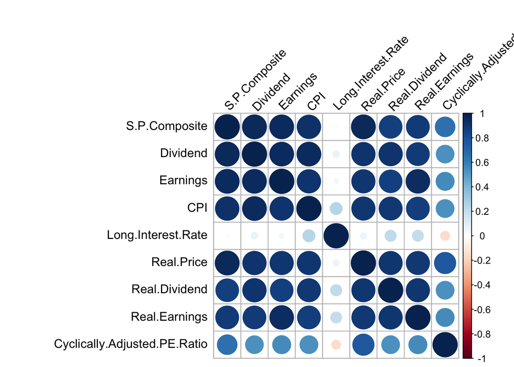

Obviously, there are collinearity between dividend and real dividend, earnings and real earnings. Therefore, we turn to obtain the VIF values of these variables.

VIF values:

```
##                     Dividend                     Earnings
##                    90.630964                    88.901893
##                          CPI           Long.Interest.Rate
##                    20.931561                     2.375851
##                   Real.Price                Real.Dividend
##                    29.378285                    32.956594
##                Real.Earnings Cyclically.Adjusted.PE.Ratio
##                    54.280547                     5.004143
```

```
##
## Call:
## lm(formula = S.P.Composite ~ ., data = data3)
##
## Residuals:
##     Min      1Q  Median      3Q     Max
## -147.12  -51.71   -7.44   55.64  375.45
##
## Coefficients:
##                               Estimate Std. Error t value Pr(>|t|)
## (Intercept)                  184.89841   10.71348   17.26  < 2e-16 ***
## CPI                            2.36787    0.08186   28.93  < 2e-16 ***
## Long.Interest.Rate           -32.39503    0.90167  -35.93  < 2e-16 ***
## Real.Price                     0.86657    0.01890   45.86  < 2e-16 ***
## Real.Dividend                -10.79104    0.69952  -15.43  < 2e-16 ***
## Real.Earnings                  0.85080    0.22568    3.77 0.000169 ***
## Cyclically.Adjusted.PE.Ratio -13.61284    0.58071  -23.44  < 2e-16 ***
## ---
## Signif. codes:  0 '***' 0.001 '**' 0.01 '*' 0.05 '.' 0.1 ' ' 1
##
## Residual standard error: 74.28 on 1625 degrees of freedom
## Multiple R-squared:  0.9762, Adjusted R-squared:  0.9762
## F-statistic: 1.113e+04 on 6 and 1625 DF,  p-value: < 2.2e-16
```

Next, we need to fit the ARMA+GARCH model to the residuals ($y_{t}^*$) of this linear regression. Before fitting this final model, it is necessary to check the time series plot of $y_{t}^*$ as well as ACF and PACF plots of both $y_{t}^*$ and $y_{t}^{*2}$ . The plots are as following:

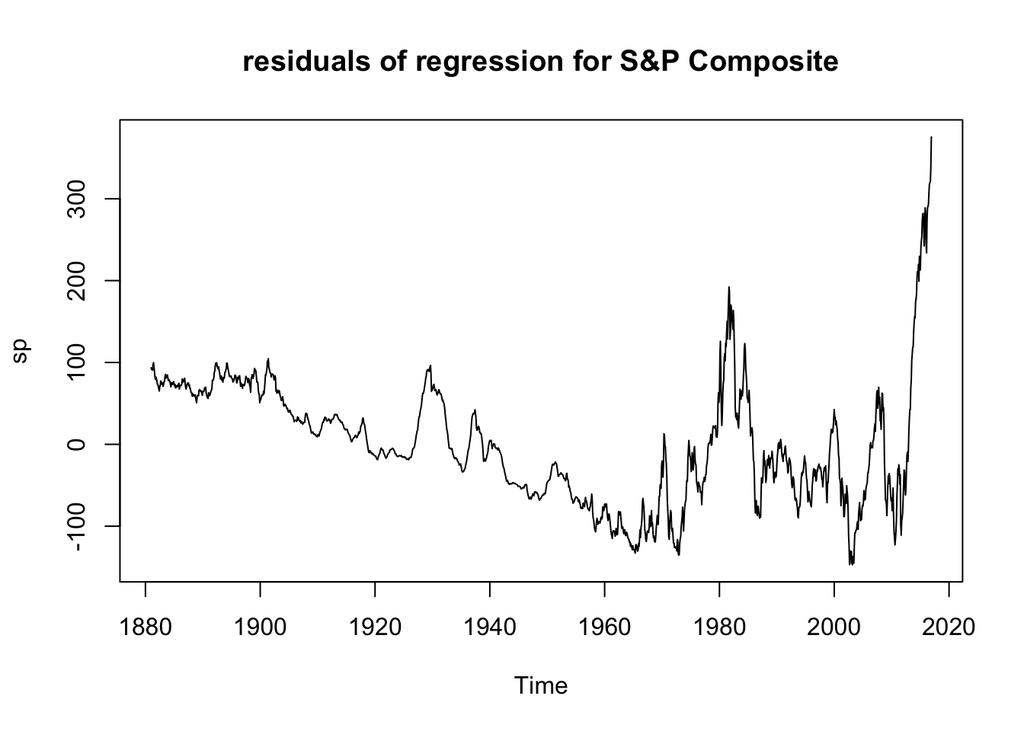

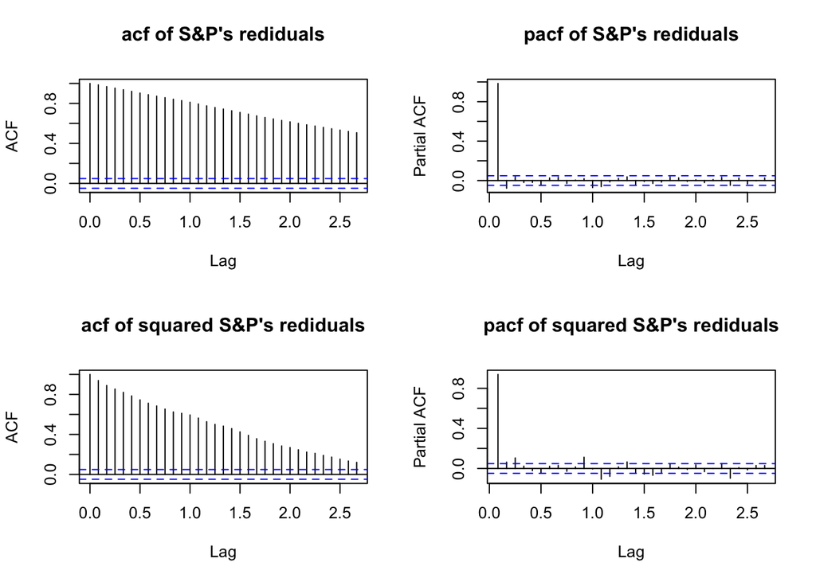

From the plots, we find obvious trend in the time series plot of the $y_{t}^*$ Also, the ACF and PACF plots are not good enough.

In addition, we need to use the Augmented Dickey-Fuller Test and Phillips-Perron test to check the stationarity of the $y_{t}^*$ and $y_{t}^{*2}$ as following:

```
##
##  Augmented Dickey-Fuller Test
##
## data:  sp
## Dickey-Fuller = -0.89051, Lag order = 11, p-value = 0.9535
## alternative hypothesis: stationary
```

```
##
##  Phillips-Perron Unit Root Test
##
## data:  sp
## Dickey-Fuller Z(alpha) = 0.10731, Truncation lag parameter = 8,
## p-value = 0.99
## alternative hypothesis: stationary
```

```
##
##  Augmented Dickey-Fuller Test
##
## data:  sp^2
## Dickey-Fuller = 5.9939, Lag order = 11, p-value = 0.99
## alternative hypothesis: stationary
```

```
##
##  Phillips-Perron Unit Root Test
##
## data:  sp^2
## Dickey-Fuller Z(alpha) = 57.284, Truncation lag parameter = 8,
## p-value = 0.99
## alternative hypothesis: stationary
```

From all p-values we obtained above, we can conclude that the residuals $y_{t}^*$ and its square are non-stationary. So, in order to remove the trend, we try to do difference of the $y_{t}^*$ and mark it as ‘sp_d’.

Following are the ACF and PACF plots of both ‘sp_d’ and the squre of the ‘sp_d’:

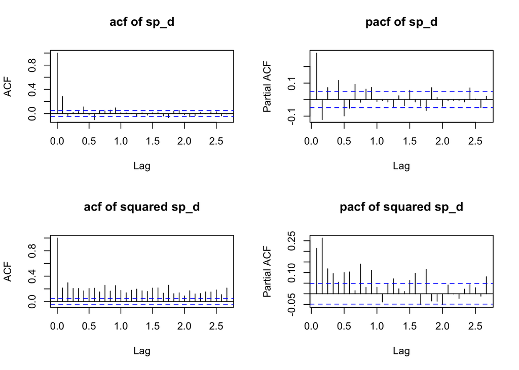

From these plots, we find that the ACF and PACF of ‘sp_d’ have some patterns and decay into blue dotted lines with the lag values increasing. In addition, the ACF and PACF plots of the square of ‘sp_d’ have obvious patterns. Therefore, these all results show that we need to fit ARMA+GARCH model to the dataset.

It is also necessary to check the stationarity again. From the ADF test and PP test following, we can reject the null hypothesis (non-stationary) and conclude that the series are stationary.

```
##
##  Augmented Dickey-Fuller Test
##
## data:  sp_d
## Dickey-Fuller = -9.6165, Lag order = 11, p-value = 0.01
## alternative hypothesis: stationary
```

```
##
##  Phillips-Perron Unit Root Test
##
## data:  sp_d
## Dickey-Fuller Z(alpha) = -1120.5, Truncation lag parameter = 8,
## p-value = 0.01
## alternative hypothesis: stationary
```

### (2) ARMA Model.

Before fitting the ARMA+GARCH model by garchfit {fGarch}, we are supposed to decide a best order for the ARMA model. So, we set loops to choose a model with the smallest BIC automatically. At last, we decide to use MA(1), whose BIC is 4.148424, to fit ‘sp_d’ as the ARMA part of the final model we will fit next.

```
##   p q      BIC
## 2 0 1 4.148424
```

```
##
## Call:
## arima(x = sp_d, order = c(0, 0, 1), method = "CSS")
##
## Coefficients:
##          ma1  intercept
##       0.3510     0.1737
## s.e.  0.0253     0.2650
##
## sigma^2 estimated as 62.76:  part log likelihood = -5689.94
```

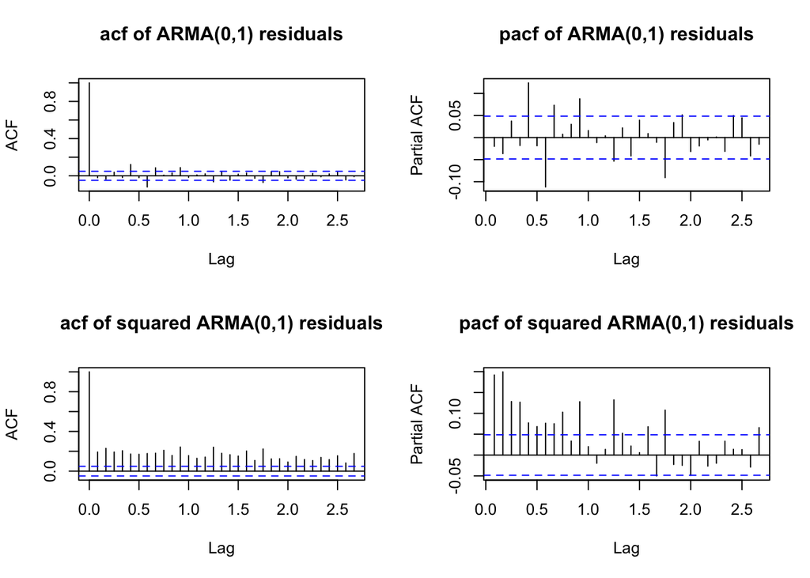

### (3) ARMA+GARCH Model.

Finally, we use the garchFit {fGarch} to fit the final model to the ‘sp_d’ as following:

#### Model 1:

We assume that the distribution of $\varepsilon_t$ is standard normal.

From the result, we can see that the Jarque-Bera test and Shapiro-Wilk test can show that the normal assumption is not suitable. The skewness and excess kurtosis exist in the model distribution assumption because the p-value is small enough.

And we also use the LM Arch test to do the diagnostic of the model. The LM Arch test (p-value=0.9763>0.05) shows that the $\varepsilon_t$ is uncorrelated, which conforms to the assumption of the GARCH-type model.

So this model is not a good fit for the data.

```
##
## Title:
##  GARCH Modelling
##
## Call:
##  garchFit(formula = ~arma(0, 1) + garch(1, 1), data = sp_d, trace = FALSE)
##
## Mean and Variance Equation:
##  data ~ arma(0, 1) + garch(1, 1)
## <environment: 0x7f92e2809580>
##  [data = sp_d]
##
## Conditional Distribution:
##  norm
##
## Coefficient(s):
##        mu        ma1      omega     alpha1      beta1
## -0.242205   0.354688   0.056162   0.162625   0.857884
##
## Std. Errors:
##  based on Hessian
##
## Error Analysis:
##         Estimate  Std. Error  t value Pr(>|t|)
## mu      -0.24221     0.08889   -2.725  0.00643 **
## ma1      0.35469     0.02386   14.864  < 2e-16 ***
## omega    0.05616     0.01183    4.746 2.07e-06 ***
## alpha1   0.16263     0.02022    8.044 8.88e-16 ***
## beta1    0.85788     0.01435   59.776  < 2e-16 ***
## ---
## Signif. codes:  0 '***' 0.001 '**' 0.01 '*' 0.05 '.' 0.1 ' ' 1
##
## Log Likelihood:
##  -4808.686    normalized:  -2.948306
##
## Description:
##  Thu Jul 12 15:30:13 2018 by user:
##
##
## Standardised Residuals Tests:
##                                 Statistic p-Value
##  Jarque-Bera Test   R    Chi^2  177.305   0
##  Shapiro-Wilk Test  R    W      0.9877136 1.540465e-10
##  Ljung-Box Test     R    Q(10)  52.58578  8.887725e-08
##  Ljung-Box Test     R    Q(15)  56.40724  1.034156e-06
##  Ljung-Box Test     R    Q(20)  57.8858   1.504999e-05
##  Ljung-Box Test     R^2  Q(10)  4.152982  0.9401819
##  Ljung-Box Test     R^2  Q(15)  5.422652  0.9879027
##  Ljung-Box Test     R^2  Q(20)  8.028439  0.9916779
##  LM Arch Test       R    TR^2   4.348674  0.9762916
##
## Information Criterion Statistics:
##      AIC      BIC      SIC     HQIC
## 5.902742 5.919287 5.902724 5.908880
```

So we try to use to use non normal conditional distribution: standard t distribution and skewed t distribution.

#### Model 2:

The Ljung-Box statistics indicate quite significant autocorrelations in standardized residuals since p-values are below 0.05, and no autocorrelations in squared standardized residuals. However, since this model is not fitted to the raw data, we use the LM Arch test to do the diagnostic of the model. The LM Arch test (p-value=0.9823>0.05) shows that the residuals are uncorrelated, which conforms to the assumption of the GARCH-type model. So we still conclude that the model does not exhibit significant lack of fit.

```
##
## Title:
##  GARCH Modelling
##
## Call:
##  garchFit(formula = ~arma(0, 1) + garch(1, 1), data = sp_d, cond.dist = "std",
##     trace = FALSE)
##
## Mean and Variance Equation:
##  data ~ arma(0, 1) + garch(1, 1)
## <environment: 0x7f92e26bf710>
##  [data = sp_d]
##
## Conditional Distribution:
##  std
##
## Coefficient(s):
##        mu        ma1      omega     alpha1      beta1      shape
## -0.208596   0.340602   0.042987   0.155234   0.865298   7.127054
##
## Std. Errors:
##  based on Hessian
##
## Error Analysis:
##         Estimate  Std. Error  t value Pr(>|t|)
## mu      -0.20860     0.08391   -2.486   0.0129 *
## ma1      0.34060     0.02317   14.697  < 2e-16 ***
## omega    0.04299     0.01775    2.422   0.0154 *
## alpha1   0.15523     0.02308    6.725 1.76e-11 ***
## beta1    0.86530     0.01643   52.662  < 2e-16 ***
## shape    7.12705     1.17927    6.044 1.51e-09 ***
## ---
## Signif. codes:  0 '***' 0.001 '**' 0.01 '*' 0.05 '.' 0.1 ' ' 1
##
## Log Likelihood:
##  -4777.167    normalized:  -2.92898
##
## Description:
##  Thu Jul 12 15:30:14 2018 by user:
##
##
## Standardised Residuals Tests:
##                                 Statistic p-Value
##  Jarque-Bera Test   R    Chi^2  193.0316  0
##  Shapiro-Wilk Test  R    W      0.987196  7.828759e-11
##  Ljung-Box Test     R    Q(10)  54.21587  4.423082e-08
##  Ljung-Box Test     R    Q(15)  57.98401  5.58274e-07
##  Ljung-Box Test     R    Q(20)  59.37679  8.888788e-06
##  Ljung-Box Test     R^2  Q(10)  3.872841  0.9529011
##  Ljung-Box Test     R^2  Q(15)  5.004109  0.9920916
##  Ljung-Box Test     R^2  Q(20)  7.926537  0.9923427
##  LM Arch Test       R    TR^2   4.059584  0.982337
##
## Information Criterion Statistics:
##      AIC      BIC      SIC     HQIC
## 5.865318 5.885172 5.865291 5.872684
```

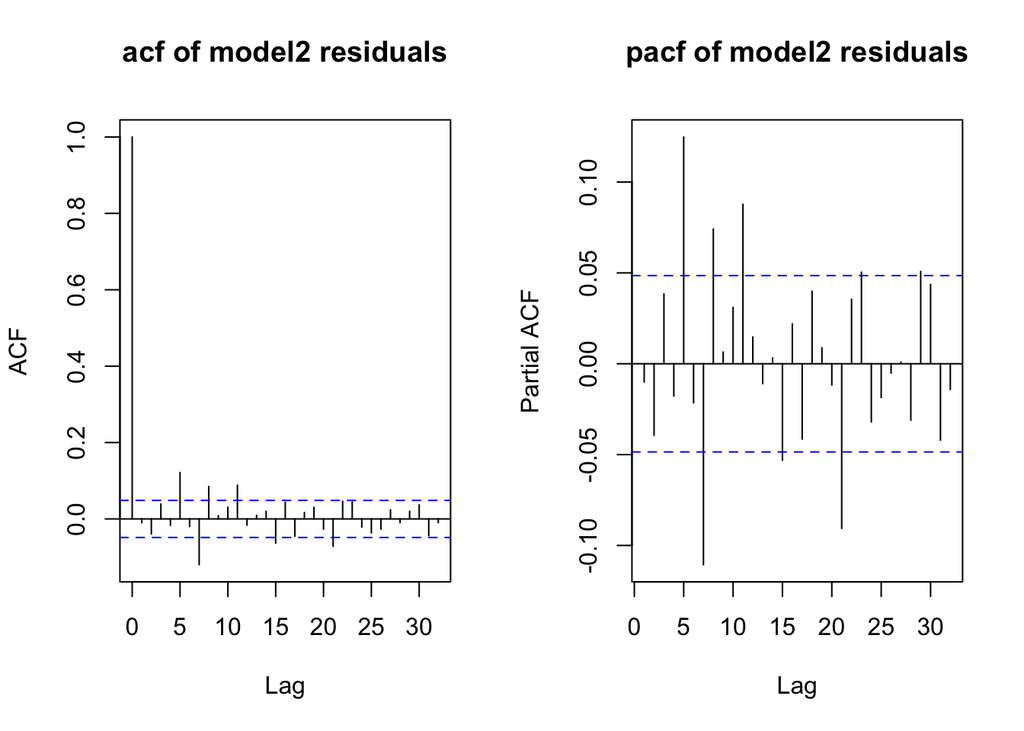

#### Model 3:

```
##
## Title:
##  GARCH Modelling
##
## Call:
##  garchFit(formula = ~arma(0, 1) + garch(1, 1), data = sp_d, cond.dist = "sstd",
##     trace = FALSE)
##
## Mean and Variance Equation:
##  data ~ arma(0, 1) + garch(1, 1)
## <environment: 0x7f92df84c778>
##  [data = sp_d]
##
## Conditional Distribution:
##  sstd
##
## Coefficient(s):
##        mu        ma1      omega     alpha1      beta1       skew
## -0.196537   0.341319   0.042295   0.154148   0.865940   1.016824
##     shape
##  7.179074
##
## Std. Errors:
##  based on Hessian
##
## Error Analysis:
##         Estimate  Std. Error  t value Pr(>|t|)
## mu      -0.19654     0.08799   -2.234   0.0255 *
## ma1      0.34132     0.02324   14.687  < 2e-16 ***
## omega    0.04229     0.01887    2.242   0.0250 *
## alpha1   0.15415     0.02297    6.711 1.93e-11 ***
## beta1    0.86594     0.01640   52.811  < 2e-16 ***
## skew     1.01682     0.03652   27.842  < 2e-16 ***
## shape    7.17907     1.19810    5.992 2.07e-09 ***
## ---
## Signif. codes:  0 '***' 0.001 '**' 0.01 '*' 0.05 '.' 0.1 ' ' 1
##
## Log Likelihood:
##  -4777.059    normalized:  -2.928914
##
## Description:
##  Thu Jul 12 15:30:15 2018 by user:
##
##
## Standardised Residuals Tests:
##                                 Statistic p-Value
##  Jarque-Bera Test   R    Chi^2  194.6455  0
##  Shapiro-Wilk Test  R    W      0.9871448 7.328576e-11
##  Ljung-Box Test     R    Q(10)  54.40042  4.086219e-08
##  Ljung-Box Test     R    Q(15)  58.17183  5.185917e-07
##  Ljung-Box Test     R    Q(20)  59.55955  8.330186e-06
##  Ljung-Box Test     R^2  Q(10)  3.860613  0.9534159
##  Ljung-Box Test     R^2  Q(15)  4.982069  0.9922771
##  Ljung-Box Test     R^2  Q(20)  7.935107  0.9922884
##  LM Arch Test       R    TR^2   4.04885   0.9825387
##
## Information Criterion Statistics:
##      AIC      BIC      SIC     HQIC
## 5.866413 5.889575 5.866376 5.875005
```

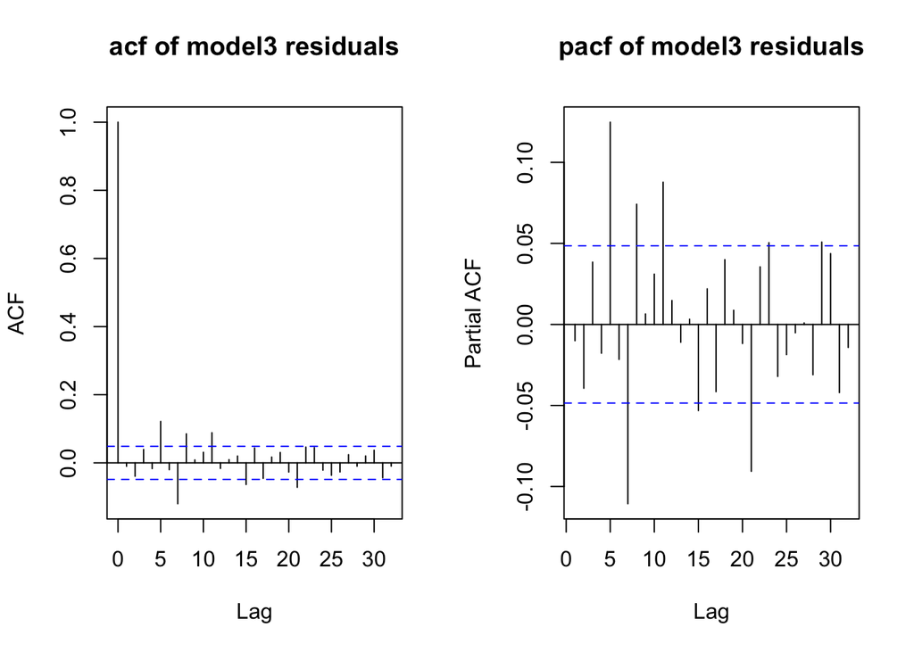

## 4. Forecasting.

Finally, we use our final GARCH-M model to forecast the S&P Composite Index from January 2017 to June 2017 as following:

2274.243, 2310.593, 2333.384, 2329.704, 2352.646, 2380.969.

Also, we compare the real observed S&P Composite Index data with our forecasting values. Their overlay time-series plot is as following:

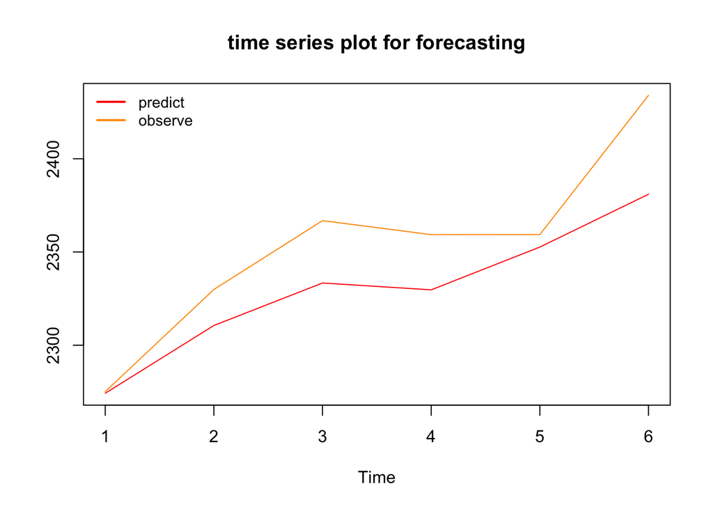

## 5. Discussion of Results and Summary.

In the next step, we can try more complex model such as APARCH, TGARCH and EGARCH, etc.

## Reference

[1] https://www.investopedia.com/ask/answers/040215/what-does-sp-500-index-measure-and-how-it-calculated.asp

[2] https://stats.stackexchange.com/questions/202526/garch-diagnostics-autocorrelation-in-standardized-residuals-but-not-in-their-sq

[3] Modeling S&P 500 STOCK INDEX using ARMA-ASYMMETRIC POWER ARCH models, Jia Zhou, Chanli He[June 2009]